# Factors Affecting Loan Statuses: A Case Study from Prospers

## by Engi Amin

## Investigation Overview

The prosper loan dataset is financial dataset that shows the current status of loans by Prosper Marketplace, Inc. Prosper is a San Francisco, California-based company specialized in peer-to-peer lending industry (https://www.prosper.com/).

The goal of this analysis is to explore the factors that affect a loan’s outcome status, especially when a loan defaults.

## Dataset Overview

The dataset consists of 113937 data entries for 81 variables including characteristics of the borrower, loan and investors. The main feature of interest (response variable) is `LoanStatus` which defines the current status of the loan.

The main selected features that would support the investigation (independent variables) are:

- `IsBorrowerHomeowner`: Borrower is a home owner.
- `DebtToIncomeRatio`: The debt to income ratio of the borrower at the time the credit profile was pulled.
- `LoanOriginalAmount`: The origination amount of the loan.

## Loan Status Distribution

The majority of loans in the dataset are still current (67.7%), 2.4% are past due and 6.8% have either been charged-off or defaulted. This puts a responsibily on risk-analysts at Prosper to keep good track of their current borrowers.

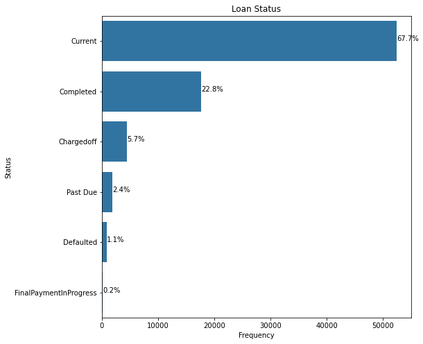

## Debt-to-Income and Loan Status

Borrowers who have defaulted have a higher median of debt-to-income ratio than all others. This is a very important red flag for risk analysts.

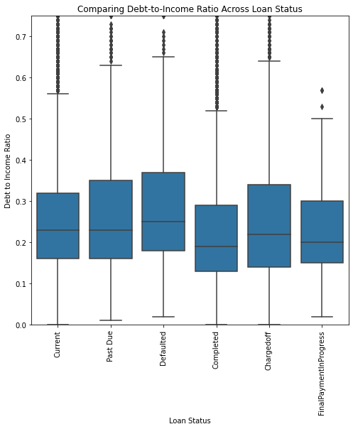

## The Interplay of Loan Original Amount, Debt to Income Ratio and Home Ownership

**Current Borrowers**

- Those who have highest debt-to-income ratio are not home owners.
- Most of current borrowers who ask for higher orginal loan amount are home owners.

**Default and Charged off Borrowers**

- Are mostly home owners.
- Have mostly asked for loans less than 20,000 dollars.

**Borrowers with Complete or almost Complete Payments**

- Are mostly home owners.
- Have mostly asked for loans less than 20,000 dollars.
- Have low debt-to-income ratio.
- Those who had the largest debt-to-income ratio were the ones who asked for lower original loan amounts.

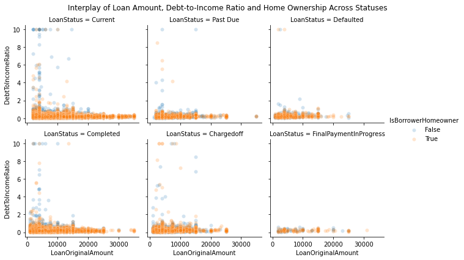